# Exercise 1.1

Joe Barry

February 20, 2021

### Question 1

First, we need to set up our equations for $Y_1(t)$ and $Y_2(t)$, along with the interval for t.

```r
t <- c(0, pi/4, pi/2, .75*pi, pi)
Y1 <- sin(t)
Y2 <- sin(t+pi/2)
print(cat("Yt1: ",Y1))
```

```
## Yt1:  0 0.7071068 1 0.7071068 1.224606e-16NULL
```

```r
print(cat("Yt2: ",Y2))
```

```
## Yt2:  1 0.7071068 1.224606e-16 -0.7071068 -1NULL
```

Here, we can see ourvalues for each equation at the points specified. These are the first two calumns of the table.

| $t$ | $Y_1(t)$ | $Y_2(t)$ | $\mu_t$ |
| --- | --- | --- | --- |
| ----------- | ---------------- | ---------------- | ---------------- |
| 0 | 0 | 1 | ? |
| $\pi/4$ | $\frac{\sqrt(2)}{2}$ | $\frac{\sqrt(2)}{2}$ | ? |
| $\pi/2$ | 1 | 0 | ? |
| $3 \pi/4$ | $\frac{\sqrt(2)}{2}$ | $\frac{-\sqrt(2)}{2}$ | ? |
| $\pi$ | 0 | -1 | ? |

Now, mu can be calculated simply by finding the average between our two Y values at each given t.

```r
mu <- (Y1+Y2)/2
print(mu)
```

```
## [1]  5.000000e-01  7.071068e-01  5.000000e-01  5.551115e-17 -5.000000e-01
```

We can now write down our full table:

| $t$ | $Y_1(t)$ | $Y_2(t)$ | $\mu_t$ |
| --- | --- | --- | --- |
| ----------- | ---------------- | ---------------- | ---------------- |
| 0 | 0 | 1 | $\frac{1}{2}$ |
| $\pi/4$ | $\frac{\sqrt(2)}{2}$ | $\frac{\sqrt(2)}{2}$ | $\frac{\sqrt(2)}{2}$ |
| $\pi/2$ | 1 | 0 | $\frac{1}{2}$ |
| $3 \pi/4$ | $\frac{\sqrt(2)}{2}$ | $\frac{-\sqrt(2)}{2}$ | 0 |
| $\pi$ | 0 | -1 | $\frac{-1}{2}$ |

### Question 2

We can start by plotting this function, which is the same as our second realization $Y_2(t)$ from the previous question, on the line $t = [0,100]$.

```r
t <- c(0:100)
Y2 <- sin(t+pi/2)

print(mean(Y2))
```

```
## [1] 0.004630806
```

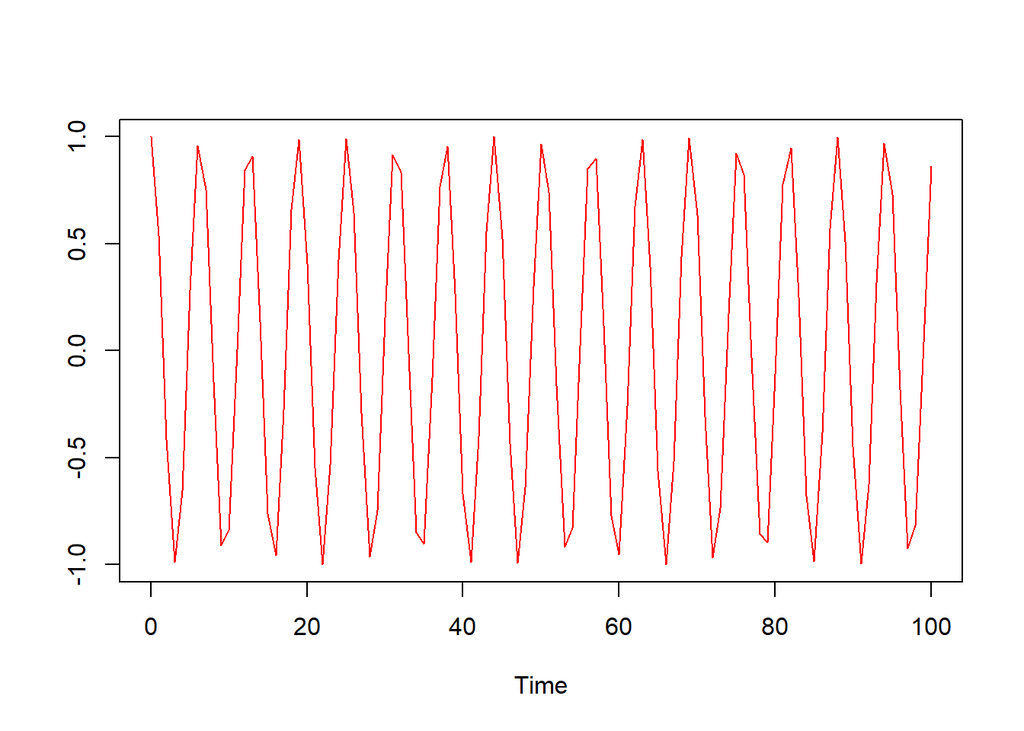

```r
plot(
  t,
  Y2,
  type = "l",
  col = "red",
  lwd = 1,
  lty = 1,
  xlab = "Time",
  ylab = NA
)
```

We can clearly see that our function simply oscillates around the value zero. On a sufficiently large set for $t$ such as this one, we can guess that the mean would be very close to zero; indeed, it is $0.004630806$.

### Question 3

An ensemble mean is made up of each individual realization for that specific time $t$. On the other hand, the mean of a realization only involves one realization, yet is averaged over a range of values for $t$.

### Question 4

We are given the following for a plot:

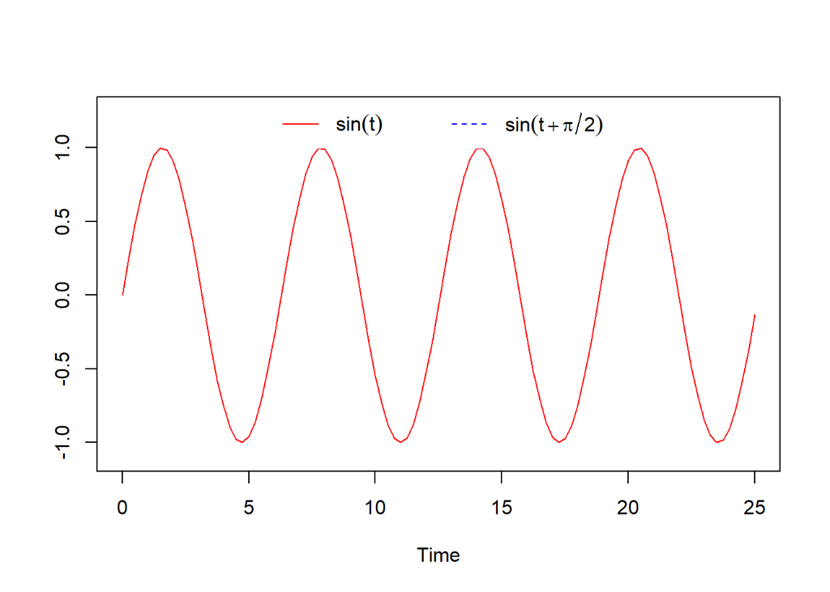

```r
# Create a sequence to 100 and scale values to (0, 25)
t <- c(0:100)
t <- t * 25/100

# Define the time series
Yt1 <- sin(t)

# Plot our time series
plot(
  t,
  Yt1,
  ylim = c(-1.1, 1.25),
  type = "l",
  col = "red",
  lwd = 1,
  lty = 1,
  xlab = "Time",
  ylab = NA
)

legend(
  "top",
  inset=0.01,
  col=c("red","blue"),
  lty=c(1,2),
  lwd=c(1,1),
  legend = c(
    expression(sin(t)),
    expression(sin(t+pi/2))),
  bg="white",
  box.col="white",
  horiz=TRUE
)
```

We can add a line to it using the lines() function. All we have to do is match the color of the line already given in the legend. $Y_2(t)$ also has to be redefined, as it was previously set on a different $t$ interval.

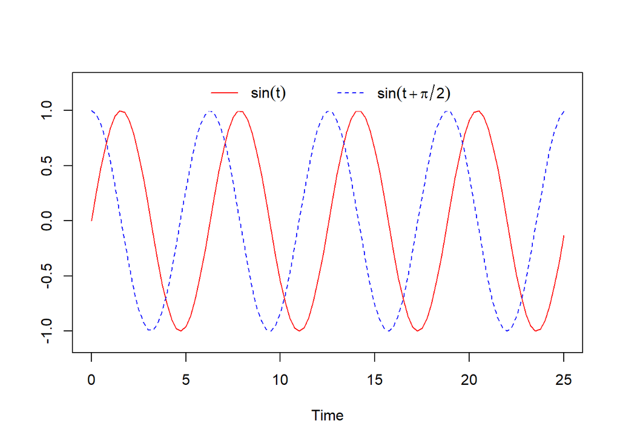

```r
Y2 <- Y2 <- sin(t+pi/2)
# Plot our time series
plot(
  t,
  Yt1,
  ylim = c(-1.1, 1.25),
  type = "l",
  col = "red",
  lwd = 1,
  lty = 1,
  xlab = "Time",
  ylab = NA
)

lines( #second line
  t,
  Y2,
  col = "blue",
  lwd = 1, #width of line
  lty = 2, #type of line
)

legend(
  "top",
  inset=0.01,
  col=c("red","blue"),
  lty=c(1,2),
  lwd=c(1,1),
  legend = c(
    expression(sin(t)),
    expression(sin(t+pi/2))),
  bg="white",
  box.col="white",
  horiz=TRUE
)
```